# Development of a Pipeline for the Benchmarking of Next-Generation Sequencing Quality Control Tools

## Key Features:

1. **Trimming Combinations:** *trimmingCombinations*: A list of different combinations for sequence processing, including quality trimming, adapter trimming, length filtering, complexity filtering, and various hybrids of these methods.
2. **The trimmingChannel:** A channel that pairs trimming parameters with file pairs, ready to be processed by downstream processes.
3. **Fastp Process:** This process uses fastp, a tool for fast and high-quality preprocessing of sequencing data. It takes paired-end reads and the trimming parameters as input and generates trimmed sequence files based on the specified parameters. The process dynamically constructs the fastp command based on the trimming combination provided, applying the relevant trimming options.
4. **SPAdes Assembly:** This process runs the SPAdes genome assembler on the trimmed reads to construct genome assemblies. It outputs the assembled scaffolds for each trimming parameter set.
5. **QUAST Quality Assessment:** This process performs quality assessment on the assembled genomes using QUAST. It generates reports for each assembly, providing insights into the quality and statistics of the assembled sequences.
6. **Workflow:** The workflow orchestrates the execution of these processes in a data-driven manner:
- *fastp_process* is executed first, receiving combinations of trimming parameters and file pairs from *trimmingChannel*. The trimmed reads are then grouped by their trimming parameters and passed to the *spades_process*.
- *spades_process* assembles the genomes from the trimmed reads and outputs the assembled scaffolds, which are collected and passed to the *quast_process*.
- *quast_process* assesses the quality of each assembled genome and generates reports.
7. **Highlights of the Workflow:**
- *Dynamic Command Construction*: The script dynamically constructs commands for fastp based on the trimming strategies, making the workflow highly flexible and adaptable to various preprocessing needs.
- *Data-driven Execution*: The workflow's execution is driven by the available data and specified parameters, ensuring efficient and parallel processing of multiple samples and trimming strategies.
- *Scalability*: By leveraging Nextflow, the workflow can be easily scaled and executed across different computational environments, from local machines to high-throughput computing clusters and cloud environments.

## Selection of trimming methods & the naming conventions:

The naming conventions used throughout the script are consistent and logical, making the code readable and understandable. Each name gives clear insight into what the variable, parameter, or process is intended for, which is crucial in complex bioinformatics workflows where clarity and precision are paramount. The naming strategy in this code aids in understanding the flow and purpose of different parts of the script, aligning well with best practices in coding for clarity, maintainability, and collaboration.

1. **Trimming Combinations:**
- The trimming combinations (e.g., *QualityTrim_Q25*, *AdapterTrim_Q25*, etc.) use a systematic approach that combines the type of trimming operation with specific parameters, separated by underscores (_).
- Type of Trimming: The first part of each name (e.g., *QualityTrim*, *AdapterTrim*) specifies the type of trimming operation, indicating what aspect of the sequence data is being trimmed (quality, adapter, etc.). When the program pipeline runs for the first time we use 5 different basic trimming methods with the most averaged parameters. Each trimming operation addresses different types of potential issues in sequencing data:
  - *Quality Trimming:* Removes regions with low sequencing quality, which can improve the accuracy of downstream analyses
  - *Adapter Trimming:* Removes adapter sequences that can interfere with read alignment and other analyses
  - *Length Filtering:* Ensures that only reads of a certain length are kept, which can be crucial for certain types of analysis like assembly
  - *Complexity Filtering:* Removes low complexity sequences that could be repetitive or non-informative
  - *Sliding Window Trimming:* Applies quality trimming in a sliding window, offering a balance between quality control and retaining as much data as possible
- Parameters: Following the underscore, the parameters are specified, often with a prefix (e.g., Q25 for a quality threshold of 25, 75 for length filtering at 75 bases, 4nt for a window size of 4 nucleotides, q25 for а mean quality threshold inside the window of 25).
- Hybrids: Names like *QualityAdapterHybrid_Q25* (containing the word *Hybrid*) suggest a combination of two trimming operations (in this case for example it's the *QualityTrim_Q25* & the *AdapterTrim_Q25*), providing a clear indication of the processes involved. The number of unique combinations (where each pair consists of two different basic trimming options of the 5 described above excluding combining any trimming methods with themselves) according to the concept of combinations without repetition (also known as "combinations without replacement") is exactly 10. Different sequencing platforms and sample preparations can introduce various types of artifacts or biases in the data. Testing different combinations allows the pipeline to be adaptable to a wide range of data types and qualities.
- In total, we will be testing 15 different trimming methods during the first run of the program pipeline, and the 16th method is called *NoTrimming*, which, as its name suggests, tells us that no trimming is used in this case. This naming consistency has a huge effect during the execution of a program pipeline. Each piece of data can be traced through the pipeline, from the initial input to the final output, including intermediate steps. All the names of the trimming methods at each step are preserved, facilitating the reproduction of results, as each step's function and input/output relationships are clearly defined. In addition, researchers or future users of the pipeline can easily understand the workflow, modify it, or extend it due to the logical and transparent naming conventions.

Demonstration of naming consistency in data streams after the first run of the program pipeline:

[figure not shown]

2. **Channel and Process Definitions:**
- Channel: Used to create a stream of data. The naming within the channel operations (*trimmingChannel*, *fastpCollectChannel*, *quastInputChannel*) is indicative of their role in the workflow, specifying both the type of data they handle and their position or function within the pipeline.
- Process: Each process is named according to the primary tool or operation it performs (*fastp_process*, *spades_process*, *quast_process*), making it straightforward to understand their role within the workflow.
3. **Input and Output:**
- input and output declarations within processes are named to reflect the data they handle, with tuples and paths indicating the nature and format of the data (e.g., tuple val(trimParams), file(reads) for input and path("${reads[0].simpleName}_${trimParams}.fastq") for output).
4. **The Pipeline:**

```
// Define input and output directory parameters
params.input_dir = 'raw_data'

// Define a list of different trimming combinations for sequence processing
def trimmingCombinations = [
  "QualityTrim_Q25",
  "AdapterTrim_Q25",
  "LengthFilter_75",
  "ComplexityFilter",
  "SlidingWindow_4nt_q25",
  "QualitySlidingHybrid_Q25_4nt_q25", // QualityTrim_Q25 + SlidingWindow_4nt_q25
  "QualityAdapterHybrid_Q25", // QualityTrim_Q25 + AdapterTrim_Q25
  "LengthComplexityHybrid_75", // LengthFilter_75 + ComplexityFilter
  "SlidingComplexityHybrid_4nt_q25", // SlidingWindow_4nt_q25 + ComplexityFilter
  "AdapterSlidingHybrid_Q25_4nt_q25", // AdapterTrim_Q25 + SlidingWindow_4nt_q25
  "QualityLengthHybrid_Q25_75", // QualityTrim_Q25 + LengthFilter_75
  "QualityComplexityHybrid_Q25", // QualityTrim_Q25 + ComplexityFilter
  "AdapterLengthHybrid_Q25_75", // AdapterTrim_Q25 + LengthFilter_75
  "AdapterComplexityHybrid_Q25", // AdapterTrim_Q25 + ComplexityFilter
  "LengthSlidingHybrid_75_4nt_Q25", // LengthFilter_75 + SlidingWindow_4nt_q25
  "NoTrimming"
]

/* Create a channel with trimming combinations
  and pair them with file pairs from the input directory
*/
Channel
  .from(trimmingCombinations)
  .combine(Channel.fromFilePairs("${params.input_dir}/*_{1,2}.fastq"))
  .map { trimParams, sampleId, files ->
    println("Trim Params: ${trimParams}, Files: ${files}")
    tuple(trimParams, files)
  }
  .set { trimmingChannel }


process fastp_process {
  label 'fastp'
  tag "${trimParams}_${reads[0].getName()}"

  input:
    tuple val(trimParams), file(reads)

  output:
    tuple val(trimParams), \
    path("${reads[0].simpleName}_${trimParams}.fastq"), \
    path("${reads[1].simpleName}_${trimParams}.fastq")

  script:
    String trimParamsStr = trimParams.toString().trim()
    def fastpCmd = "fastp --in1 ${reads[0]} --in2 ${reads[1]}"
    String outputFileName1 = "${reads[0].simpleName}_${trimParams}.fastq"
    String outputFileName2 = "${reads[1].simpleName}_${trimParams}.fastq"
    fastpCmd += " --out1 ${outputFileName1} --out2 ${outputFileName2}"

    String htmlReport = "${reads[0].simpleName}_${trimParams}.html"
    String jsonReport = "${reads[0].simpleName}_${trimParams}.json"
    fastpCmd += " --html ${htmlReport} --json ${jsonReport}"

    def parts = trimParamsStr.tokenize('_')

    def trimActionMap = [
    QualityTrim: { String q ->
      "--qualified_quality_phred ${q.replace('Q', '')}"
    },
    AdapterTrim: { String q ->
      "--detect_adapter_for_pe --qualified_quality_phred " +
      "${q.replace('Q', '')}"
    },
    LengthFilter: { String length ->
      "--length_required ${length}"
    },
    ComplexityFilter: { _ ->
      "--low_complexity_filter"
    },
    SlidingWindow: { String windowSize, String meanQuality ->
      "--cut_right --cut_window_size ${windowSize.replace('nt', '')} " +
      "--cut_mean_quality ${meanQuality.replace('q', '')}"
    },
    QualitySlidingHybrid: { String q, String windowSize, String meanQuality ->
      "--cut_right --qualified_quality_phred ${q.replace('Q', '')} " +
      "--cut_window_size ${windowSize.replace('nt', '')} " +
      "--cut_mean_quality ${meanQuality.replace('q', '')}"
    },
    QualityAdapterHybrid: { String q ->
      "--detect_adapter_for_pe --qualified_quality_phred " +
      "${q.replace('Q', '')}"
    },
    LengthComplexityHybrid: { String length ->
      "--length_required ${length} --low_complexity_filter"
    },
    SlidingComplexityHybrid: { String windowSize, String meanQuality ->
      "--cut_right --cut_window_size ${windowSize.replace('nt', '')} " +
      "--cut_mean_quality ${meanQuality.replace('q', '')} " +
      "--low_complexity_filter"
    },
    AdapterSlidingHybrid: { String q, String windowSize, String meanQuality ->
      "--detect_adapter_for_pe --cut_right --cut_window_size " +
      "${windowSize.replace('nt', '')} --cut_mean_quality " +
      "${meanQuality.replace('q', '')} --qualified_quality_phred " +
      "${q.replace('Q', '')}"
    },
    QualityLengthHybrid: { String q, String length ->
      "--qualified_quality_phred ${q.replace('Q', '')} " +
      "--length_required ${length}"
    },
    QualityComplexityHybrid: { String q ->
      "--qualified_quality_phred ${q.replace('Q', '')} --low_complexity_filter"
    },
    AdapterLengthHybrid: { String q, String length ->
      "--detect_adapter_for_pe --qualified_quality_phred " +
      "${q.replace('Q', '')} --length_required ${length}"
    },
    AdapterComplexityHybrid: { String q ->
      "--detect_adapter_for_pe --qualified_quality_phred " +
      "${q.replace('Q', '')} --low_complexity_filter"
    },
    LengthSlidingHybrid: {
      String length, String windowSize, String meanQuality ->
      "--length_required ${length} --cut_right --cut_window_size " +
      "${windowSize.replace('nt', '')} --cut_mean_quality " +
      "${meanQuality.replace('Q', '')}"
    },
    NoTrimming: { _ ->
      "--disable_adapter_trimming --disable_quality_filtering " +
      "--disable_length_filtering"
    }
    ]

    trimActionMap.each { key, action ->
    if (trimParamsStr.startsWith(key)) {
        fastpCmd += " " + action(parts.drop(1))
        return
      }
    }

    """
    set -euo pipefail
    echo "Trimming parameters: ${trimParams}"
    if [ ${reads.size()} -ne 2 ]; then
      echo "Error: Expected two reads files, but got ${reads.size()}"
      exit 1
    fi
    ${fastpCmd}
    echo "fastp process for ${trimParams}_"\
    "${reads[0].getName()} completed successfully."
    """
}


process spades_process {
  label 'spades'
  tag "${trimParams}"

  input:
    tuple val(trimParams), path(read1), path(read2)

  output:
    path "scaffolds_${trimParams}.fasta"

  cpus 4
  memory '8 GB'

  script:
    """
    set -euo pipefail
    echo "Read1: ${read1}"
    echo "Read2: ${read2}"
    echo "Starting SPAdes genome assembly for ${trimParams}..."
    spades.py --isolate -1 ${read1} -2 ${read2} -o output_${trimParams}
    mv output_${trimParams}/scaffolds.fasta scaffolds_${trimParams}.fasta
    echo "SPAdes genome assembly for ${trimParams} completed successfully."
    """
}


process quast_process {
  label 'quast'

  input:
    path genomes

  output:
    path "reports"

  cpus 4
  memory '8 GB'

  script:
    """
    mkdir -p reports
    set -euo pipefail
    for genome in ${genomes}
    do
      genome_name=\$(basename \$genome .fasta)
      echo "Starting QUAST quality assessment for \$genome_name..."
      quast.py -o reports/output_\${genome_name} \${genome}
      mv reports/output_\${genome_name}/report.html \
        reports/report_\${genome_name}.html
      echo "QUAST quality assessment for \$genome_name completed."
    done
    """
}


workflow {
  fastp_process(trimmingChannel)
    .groupTuple()
    .set { fastpCollectChannel }

  spades_process(fastpCollectChannel)
    .collect()
    .set { quastInputChannel }

  quast_process(quastInputChannel)
}
```

## The code provided below is designed to demonstrate the data generated by the program pipeline

To begin with, the method *extract_required_metrics(report_path)* is created that pulls all the necessary metrics from the initial reports and creates a data frame and a convenient table based on them:

```python
import pandas as pd
import os

# Function to extract required metrics from a report file
def extract_required_metrics(report_path):
    try:
        # Reading the report file
        df = pd.read_csv(report_path, sep='\t', header=None, names=['Metric', 'Value'])

        # Dictionary to store extracted metrics
        metrics = {}

        # List of key metrics to extract
        required_metrics = [
            ('Total length', 'Total length'),
            ('GC', 'GC (%)'),
            ('Largest contig', 'Largest Contig'),
            ('N50', 'N50'),
            ('N90', 'N90'),
            ('L50', 'L50'),
            ('L90', 'L90'),
            ('# N\'s per 100 kbp', '# N\'s per 100 kbp')
        ]

        # Extracting and saving the values of required metrics
        for metric_pattern, metric_name in required_metrics:
            metric_value = df[df['Metric'].str.contains(metric_pattern, case=False, regex=False)]['Value'].values
            if metric_value.size > 0:
                metrics[metric_name] = metric_value[0]
            else:
                metrics[metric_name] = 'N/A'  # Marking as 'N/A' if the metric is missing

        return metrics
    except Exception as e:
        print(f"Error processing {report_path}: {e}")
        return None

# Path to the directory containing report files
reports_dir = './reports'

# List of report files
report_files = [file for file in os.listdir(reports_dir) if file.endswith('.tsv')]

# Extracting and saving data from all report files
all_metrics_data = {}
for report_file in report_files:
    # Forming the full path to the report file
    report_path = os.path.join(reports_dir, report_file)
    # Determining the trimming parameter name from the report file name
    trimming_param = report_file.replace('report_scaffolds_', '').replace('.tsv', '')
    # Extracting metrics
    metrics = extract_required_metrics(report_path)
    if metrics:
        all_metrics_data[trimming_param] = metrics

# Converting the data into a DataFrame
all_metrics_df = pd.DataFrame.from_dict(all_metrics_data, orient='index').reset_index()
all_metrics_df.rename(columns={'index': 'Trimming Parameters'}, inplace=True)

# List of trimming parameters in the desired order
sorting_order = [
    "NoTrimming",
    "QualityTrim_Q25",
    "AdapterTrim_Q25",
    "LengthFilter_75",
    "ComplexityFilter",
    "SlidingWindow_4nt_q25",
    "QualitySlidingHybrid_Q25_4nt_q25",
    "QualityAdapterHybrid_Q25",
    "LengthComplexityHybrid_75",
    "SlidingComplexityHybrid_4nt_q25",
    "AdapterSlidingHybrid_Q25_4nt_q25",
    "QualityLengthHybrid_Q25_75",
    "QualityComplexityHybrid_Q25",
    "AdapterLengthHybrid_Q25_75",
    "AdapterComplexityHybrid_Q25",
    "LengthSlidingHybrid_75_4nt_Q25",
]

# Sorting the DataFrame according to the specified order
sorted_metrics_df = all_metrics_df.set_index('Trimming Parameters').reindex(sorting_order).reset_index()

sorted_metrics_df
```

|  | Trimming Parameters | Total length | GC (%) | Largest Contig | N50 | N90 | L50 | L90 | # N's per 100 kbp |
| --- | --- | --- | --- | --- | --- | --- | --- | --- | --- |
| 0 | NoTrimming | 4404338 | 65.49 | 209132 | 74608 | 21687 | 18 | 57 | 9.20 |
| 1 | QualityTrim_Q25 | 4347132 | 65.39 | 206803 | 64262 | 17217 | 20 | 68 | 7.43 |
| 2 | AdapterTrim_Q25 | 4347132 | 65.39 | 206803 | 64262 | 17217 | 20 | 68 | 7.43 |
| 3 | LengthFilter_75 | 4371727 | 65.42 | 209097 | 65136 | 17421 | 19 | 64 | 6.94 |
| 4 | ComplexityFilter | 4370526 | 65.41 | 209097 | 65136 | 17421 | 19 | 64 | 6.94 |
| 5 | SlidingWindow_4nt_q25 | 4338271 | 65.45 | 173819 | 56417 | 16144 | 26 | 81 | 7.86 |
| 6 | QualitySlidingHybrid_Q25_4nt_q25 | 4338271 | 65.45 | 173819 | 56417 | 16144 | 26 | 81 | 7.86 |
| 7 | QualityAdapterHybrid_Q25 | 4347132 | 65.39 | 206803 | 64262 | 17217 | 20 | 68 | 7.43 |
| 8 | LengthComplexityHybrid_75 | 4371727 | 65.42 | 209097 | 65136 | 17421 | 19 | 64 | 6.94 |
| 9 | SlidingComplexityHybrid_4nt_q25 | 4338271 | 65.45 | 173819 | 56417 | 16144 | 26 | 81 | 7.86 |
| 10 | AdapterSlidingHybrid_Q25_4nt_q25 | 4338271 | 65.45 | 173819 | 56417 | 16144 | 26 | 81 | 7.86 |
| 11 | QualityLengthHybrid_Q25_75 | 4348087 | 65.39 | 206803 | 64262 | 17217 | 20 | 69 | 7.42 |
| 12 | QualityComplexityHybrid_Q25 | 4348353 | 65.39 | 206803 | 64262 | 17387 | 20 | 67 | 7.43 |
| 13 | AdapterLengthHybrid_Q25_75 | 4348087 | 65.39 | 206803 | 64262 | 17217 | 20 | 69 | 7.42 |
| 14 | AdapterComplexityHybrid_Q25 | 4348353 | 65.39 | 206803 | 64262 | 17387 | 20 | 67 | 7.43 |
| 15 | LengthSlidingHybrid_75_4nt_Q25 | 4315732 | 65.40 | 173819 | 54049 | 16002 | 27 | 84 | 9.06 |

## After that, we would like to visualize the same data, but in a more expressive way.

To do this, we first define the base values for the **"NoTrimming"** Trimming Parameters, assuming that this is the control group or standard condition to which all other values will be compared.

Next, we'll deal with data normalization: we'll initialize an empty *rows_list* to store the normalized rows. In a loop over each row of the original DataFrame, computes the normalized deviations for each metric compared to the base values of the **"NoTrimming"** Trimming Parameters. If the base value of a metric is 0, the normalized deviation is set to 0 to avoid division by zero.

Next, a new DataFrame *norm_deviations* is created from the *rows_list* of dictionaries, where each dictionary is a row with normalized values.

### Data visualisation:

Using *seaborn.heatmap()*, we create a heatmap to visualize the normalized deviations of genome assembly metrics relative to the **"NoTrimming"** method.

In the heatmap, the rows correspond to the different trimming methods (Trimming Parameters) and the columns correspond to the genome assembly metrics.

The colors of the heatmap cells reflect the magnitude of the normalized deviations, centered at 0, where shades of red indicate positive deviation and shades of blue indicate negative deviation.

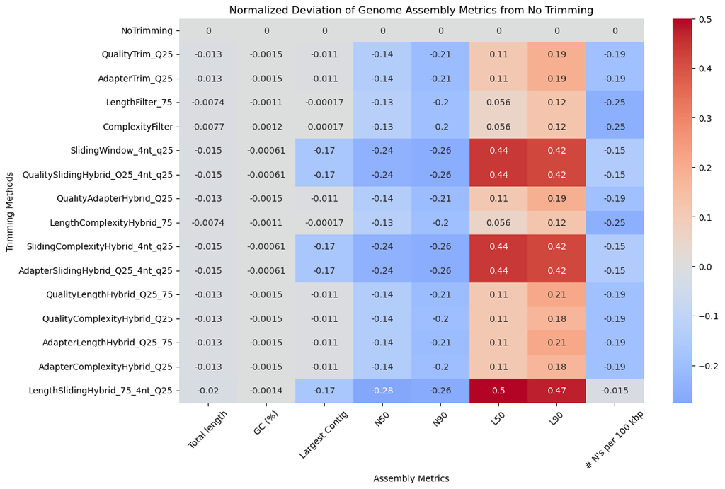

```python
import seaborn as sns
import matplotlib.pyplot as plt

# Prepare the data
# Make sure the data is numerical.
for column in sorted_metrics_df.columns[1:]:  # Skip the first column with the names of trimming methods
    sorted_metrics_df[column] = pd.to_numeric(sorted_metrics_df[column], errors='coerce')

# Find the base values for "NoTrimming"
base_values = sorted_metrics_df[sorted_metrics_df['Trimming Parameters'] == 'NoTrimming'].iloc[0, 1:]

# Initialization of the list for storing strings
rows_list = []

# Cycle to fill the list of rows
for index, row in sorted_metrics_df.iterrows():
    norm_row = {'Trimming Parameters': row['Trimming Parameters']}
    for metric in sorted_metrics_df.columns[1:]:
        if base_values[metric] != 0:
            norm_row[metric] = (row[metric] - base_values[metric]) / base_values[metric]
        else:
            norm_row[metric] = 0
    rows_list.append(norm_row)

# Creating a DataFrame from a list of strings
norm_deviations = pd.DataFrame(rows_list, columns=sorted_metrics_df.columns)

# Visualization of normalized deviations using a heat map
plt.figure(figsize=(12, 8))
sns.heatmap(norm_deviations.iloc[:, 1:], annot=True, cmap='coolwarm', center=0, yticklabels=norm_deviations['Trimming Parameters'])
plt.title('Normalized Deviation of Genome Assembly Metrics from No Trimming')
plt.xlabel('Assembly Metrics')
plt.ylabel('Trimming Methods')
plt.xticks(rotation=45)  # Rotate signatures for better readability
plt.show()
```

### Analyzing the Normalized Deviation of Genome Assembly Metrics from No Trimming:

First of all, we observe that Total length and GC (%) values remain almost unchanged after applying different trimming methods. This may indicate that different data trimming methods produce consistent results for these key parameters. This is a good sign indicating the reproducibility and reliability of the genome assembly process. This may also indicate that trimming methods do not significantly affect the overall genome profile, at least in terms of total length and GC content. That is, trimming methods can effectively remove low-quality or undesirable portions of the data without losing significant genomic regions. The consistency of these metrics may also reflect the high quality of the original sequencing data. If the sequencing data were of high quality with minimal low-quality regions, trimming may have minimal impact on the overall length and GC content of the assembly.

The second thing that catches the eye is the red color in the heat map in all data where the **Sliding Window** trimming method was used: **SlidingWindow_4nt_q25**, **QualitySlidingHybrid_Q25_4nt_q25**, **SlidingComplexityHybrid_4nt_q25**, **AdapterSlidingHybrid_Q25_4nt_q25**, **LengthSlidingHybrid_75_4nt_Q25**.

Any combination with this trimming method leads to a rather large decrease in the N50 and N90 metrics relative to the value when trimming is not used. This indicates that this trimming method, in any chosen combination, leads to a decrease in genome assembly continuity and accuracy. Most likely, this trimming method may be too aggressive and remove significant portions of the sequenced data. It is possible that this trimming method results in the removal or alteration of DNA regions that are important for proper genome assembly, which affects the final length of the contigs.

In addition, all of the above combinations increase the L50 and L90 values. This means that more contigs are now required to reach 50% or 90% of the total genome assembly length, which may be the result of increased assembly fragmentation. This may indicate a decrease in assembly continuity and is likely due to the removal of significant data and the probable removal of overlaps required to assemble contigs into larger assemblies.

**What conclusions can be drawn from this?**

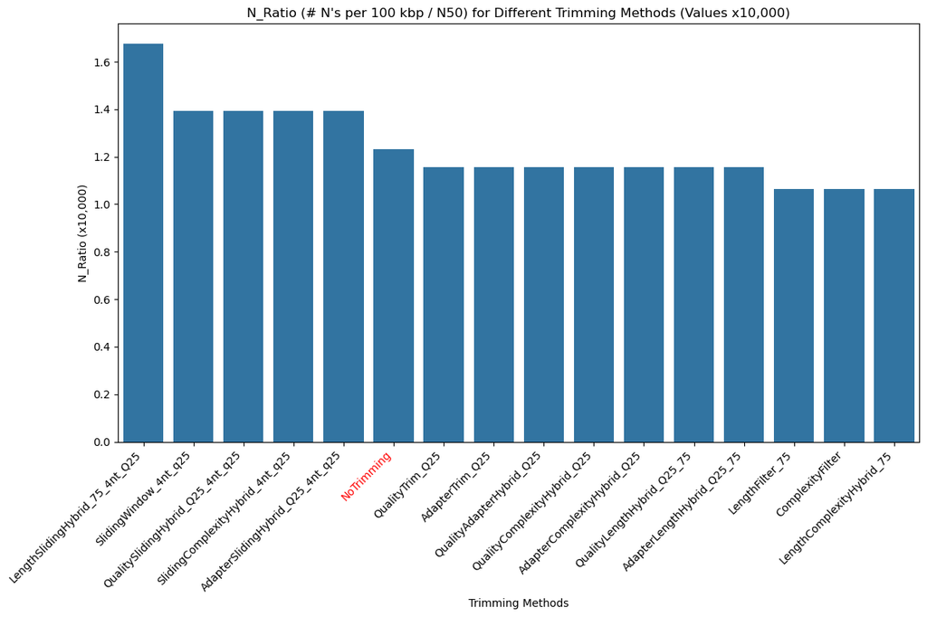

```python
# Calculate the relationship and add it as a new column to the DataFrame multiplying the result by 10,000
sorted_metrics_df['N_Ratio_x10k'] = (sorted_metrics_df['# N\'s per 100 kbp'] / sorted_metrics_df['N50']) * 10000

# Sort the DataFrame by the new column 'N_Ratio'
sorted_df = sorted_metrics_df.sort_values(by='N_Ratio_x10k', ascending=False)

# Visualisation on one common graph
plt.figure(figsize=(12, 8))
barplot = sns.barplot(x='Trimming Parameters', y='N_Ratio_x10k', data=sorted_df)

plt.title('N_Ratio (# N\'s per 100 kbp / N50) for Different Trimming Methods (Values x10,000)')
plt.xlabel('Trimming Methods')
plt.ylabel('N_Ratio (x10,000)')

# Change the colour of the 'NoTrimming' signature to red
for label in barplot.get_xticklabels():
    if label.get_text() == 'NoTrimming':
        label.set_color('red')

plt.xticks(rotation=45, ha='right')  # Tilt signatures for better readability

plt.tight_layout()
plt.show()
```

### Analyzing 16 bar plots "N_Ratio (# N's per 100 kbp / N50) for Different Trimming Methods (Values x10,000)":

Above all, if we consider the compromise between reducing the continuity of the assembly (decreasing metric N50) and reducing the number of uncertain nucleotides (denoted as 'N') in the genome assembly for every 100,000 base pairs (indicating improved assembly quality, with fewer gaps and uncertain sites in the genomic sequence), we can observe that all trimming methods have performed better than the situation where no trimming method is used, except for all combinations of the **Sliding Window** method. From this point of view, there is no justification for using these trimming methods. On the other hand, the trimming methods **LengthFilter_75**, **ComplexityFilter** and their hybrid **LengthComplexityHybrid_75** show the best result in this metric.

**What conclusions can be drawn from this?**

1. In such a situation, it would be useful to examine in more detail the two extremes: the worst trimming method (**Sliding Window**) and the best trimming method with different parameters (**Length Filter**) in terms of this compromise. Then compare them in detail with the situation where no trimming is used (**NoTrimming**).
2. We run the programming pipeline again with the same raw sequencing data, but with a variety of different parameters for the two trimming methods selected above. The following 16 parameters for **Sliding Window** & 6 parameters for **Length Filter** were selected for the new run:
   - SlidingWindow_4nt_q15
   - SlidingWindow_4nt_q20
   - SlidingWindow_4nt_q25
   - SlidingWindow_4nt_q30
   - SlidingWindow_7nt_q15
   - SlidingWindow_7nt_q20
   - SlidingWindow_7nt_q25
   - SlidingWindow_7nt_q30
   - SlidingWindow_10nt_q15
   - SlidingWindow_10nt_q20
   - SlidingWindow_10nt_q25
   - SlidingWindow_10nt_q30
   - SlidingWindow_20nt_q15
   - SlidingWindow_20nt_q20
   - SlidingWindow_20nt_q25
   - SlidingWindow_20nt_q30
   - LengthFilter_50
   - LengthFilter_75
   - LengthFilter_100
   - LengthFilter_150
   - LengthFilter_200
   - LengthFilter_250

```python
# New path to the directory with reports
second_reports_dir = './reports_2'

# List of report files in a new directory
second_report_files = [file for file in os.listdir(second_reports_dir) if file.endswith('.tsv')]

# Extracting and saving data from all report files
second_all_metrics_data = {}
for report_file in second_report_files:
    # Forming the full path to the report file
    second_report_path = os.path.join(second_reports_dir, report_file)
    # Determining the trimming parameter name from the second report file name
    second_trimming_param = report_file.replace('output_scaffolds_', '').replace('.tsv', '')
    # Extracting metrics
    second_metrics = extract_required_metrics(second_report_path)
    if second_metrics:
        second_all_metrics_data[second_trimming_param] = second_metrics

# Converting the data into a DataFrame
second_all_metrics_df = pd.DataFrame.from_dict(second_all_metrics_data, orient='index').reset_index()
second_all_metrics_df.rename(columns={'index': 'Trimming Parameters'}, inplace=True)

# List of trimming parameters in the desired order
second_sorting_order = [
    "NoTrimming",
    "SlidingWindow_4nt_q15",
    "SlidingWindow_4nt_q20",
    "SlidingWindow_4nt_q25",
    "SlidingWindow_4nt_q30",
    "SlidingWindow_7nt_q15",
    "SlidingWindow_7nt_q20",
    "SlidingWindow_7nt_q25",
    "SlidingWindow_7nt_q30",
    "SlidingWindow_10nt_q15",
    "SlidingWindow_10nt_q20",
    "SlidingWindow_10nt_q25",
    "SlidingWindow_10nt_q30",
    "SlidingWindow_20nt_q15",
    "SlidingWindow_20nt_q20",
    "SlidingWindow_20nt_q25",
    "SlidingWindow_20nt_q30",
    "LengthFilter_50",
    "LengthFilter_75",
    "LengthFilter_100",
    "LengthFilter_150",
    "LengthFilter_200",
    "LengthFilter_250",
]

# Sorting the DataFrame according to the specified order
second_sorted_metrics_df = second_all_metrics_df.set_index('Trimming Parameters').reindex(second_sorting_order).reset_index()

second_sorted_metrics_df
```

|  | Trimming Parameters | Total length | GC (%) | Largest Contig | N50 | N90 | L50 | L90 | # N's per 100 kbp |
| --- | --- | --- | --- | --- | --- | --- | --- | --- | --- |
| 0 | NoTrimming | 4404338 | 65.49 | 209132 | 74608 | 21687 | 18 | 57 | 9.20 |
| 1 | SlidingWindow_4nt_q15 | 4371714 | 65.47 | 209097 | 66370 | 19392 | 19 | 61 | 7.14 |
| 2 | SlidingWindow_4nt_q20 | 4355072 | 65.47 | 196013 | 66370 | 16891 | 19 | 66 | 6.92 |
| 3 | SlidingWindow_4nt_q25 | 4338271 | 65.45 | 173819 | 56417 | 16144 | 26 | 81 | 7.86 |
| 4 | SlidingWindow_4nt_q30 | 4324613 | 65.42 | 156069 | 45172 | 12240 | 31 | 100 | 4.64 |
| 5 | SlidingWindow_7nt_q15 | 4386621 | 65.47 | 209097 | 70975 | 20667 | 18 | 59 | 11.52 |
| 6 | SlidingWindow_7nt_q20 | 4371385 | 65.48 | 196013 | 65416 | 16973 | 20 | 65 | 11.75 |
| 7 | SlidingWindow_7nt_q25 | 4352562 | 65.46 | 196013 | 64262 | 16735 | 22 | 70 | 7.39 |
| 8 | SlidingWindow_7nt_q30 | 4335609 | 65.44 | 161559 | 53760 | 15315 | 27 | 84 | 10.41 |
| 9 | SlidingWindow_10nt_q15 | 4389356 | 65.48 | 209097 | 74525 | 20679 | 18 | 57 | 11.51 |
| 10 | SlidingWindow_10nt_q20 | 4426558 | 65.49 | 141613 | 49888 | 14028 | 29 | 91 | 20.93 |
| 11 | SlidingWindow_10nt_q25 | 4359481 | 65.47 | 196013 | 65247 | 16891 | 20 | 66 | 7.15 |
| 12 | SlidingWindow_10nt_q30 | 4337191 | 65.45 | 141533 | 53760 | 16002 | 27 | 83 | 8.33 |
| 13 | SlidingWindow_20nt_q15 | 4390654 | 65.47 | 209097 | 70975 | 20679 | 18 | 58 | 9.21 |
| 14 | SlidingWindow_20nt_q20 | 4377137 | 65.47 | 196013 | 66370 | 19418 | 19 | 61 | 6.91 |
| 15 | SlidingWindow_20nt_q25 | 4369502 | 65.47 | 196013 | 65416 | 17217 | 21 | 66 | 11.75 |
| 16 | SlidingWindow_20nt_q30 | 4347271 | 65.46 | 161570 | 64262 | 16677 | 23 | 74 | 10.16 |
| 17 | LengthFilter_50 | 4370507 | 65.41 | 209097 | 65136 | 17421 | 19 | 64 | 6.94 |
| 18 | LengthFilter_75 | 4371727 | 65.42 | 209097 | 65136 | 17421 | 19 | 64 | 6.94 |
| 19 | LengthFilter_100 | 4371227 | 65.42 | 209075 | 64713 | 17421 | 20 | 65 | 6.94 |
| 20 | LengthFilter_150 | 4371488 | 65.42 | 205948 | 64262 | 17416 | 20 | 66 | 6.94 |
| 21 | LengthFilter_200 | 4368193 | 65.42 | 205900 | 64262 | 17416 | 20 | 66 | 7.18 |
| 22 | LengthFilter_250 | 4431464 | 65.42 | 146203 | 41434 | 14197 | 34 | 102 | 16.41 |

## Let's visualize the data, but in a more expressive way again using a heat map:

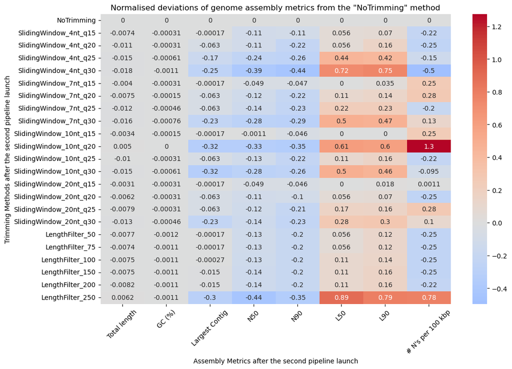

```python
# Prepare the data
# Make sure the data is numerical.
for column in second_sorted_metrics_df.columns[1:]:  # Skip the first column with the names of trimming methods
    second_sorted_metrics_df[column] = pd.to_numeric(second_sorted_metrics_df[column], errors='coerce')

base_values = second_sorted_metrics_df[second_sorted_metrics_df['Trimming Parameters'] == 'NoTrimming'].iloc[0, 1:]

# Initialising a list for storing strings
second_rows_list = []

# Cycle to fill the list of rows
for index, row in second_sorted_metrics_df.iterrows():
    second_norm_row = {'Trimming Parameters': row['Trimming Parameters']}
    for metric in second_sorted_metrics_df.columns[1:]:
        if base_values[metric] != 0:
            second_norm_row[metric] = (row[metric] - base_values[metric]) / base_values[metric]
        else:
            second_norm_row[metric] = 0
    second_rows_list.append(second_norm_row)

# Creating a data frame from a list of strings
second_norm_deviations = pd.DataFrame(second_rows_list, columns=second_sorted_metrics_df.columns)

# Visualisation of normalized deviations using a heat map
plt.figure(figsize=(12, 8))
sns.heatmap(second_norm_deviations.iloc[:, 1:], annot=True, cmap='coolwarm', center=0, yticklabels=second_norm_deviations['Trimming Parameters'])
plt.title('Normalised deviations of genome assembly metrics from the "NoTrimming" method')
plt.xlabel('Assembly Metrics after the second pipeline launch')
plt.ylabel('Trimming Methods after the second pipeline launch')
plt.xticks(rotation=45)  # Rotate signatures for better readability
plt.show()
```

### Analyzing the Normalized Deviation of Genome Assembly Metrics from No Trimming after the second pipeline launch:

We can observe the same traceable pattern as in the previous heatmap: as the # N's per 100 kbp_ parameter decreases, the _N50 (N90) parameters also decrease, while the L50 (L90) parameters increase. However, there are situations in which trimming is so terrible that there is an increase in the parameter # N's per 100 kbp while the other parameters remain relatively unchanged (**SlidingWindow_7nt_q15** and **SlidingWindow_7nt_q15**), not to mention such sharp reductions in the quality of genomic assembly as with the parameters **SlidingWindow_10nt_q20** and **LengthFilter_250**.

Let's dive deeper into the parameter study again and construct an additional Plot to demonstrate the hierarchy of trimming methods with respect to their ratio of the frequency of occurrence of uncertain nucleotides to the parameter N50.

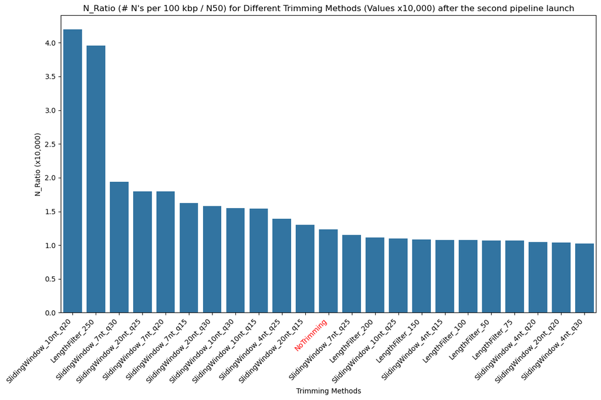

```python
# Calculate the relationship and add it as a new column to the DataFrame multiplying the result by 10,000
second_sorted_metrics_df['N_Ratio_x10k'] = (second_sorted_metrics_df['# N\'s per 100 kbp'] / second_sorted_metrics_df['N50']) * 10000

# Sort the DataFrame by the new column 'N_Ratio'
second_sorted_df = second_sorted_metrics_df.sort_values(by='N_Ratio_x10k', ascending=False)

# Visualisation on one common graph
plt.figure(figsize=(12, 8))
barplot = sns.barplot(x='Trimming Parameters', y='N_Ratio_x10k', data=second_sorted_df)

plt.title('N_Ratio (# N\'s per 100 kbp / N50) for Different Trimming Methods (Values x10,000) after the second pipeline launch')
plt.xlabel('Trimming Methods')
plt.ylabel('N_Ratio (x10,000)')

# Change the colour of the 'NoTrimming' signature to red
for label in barplot.get_xticklabels():
    if label.get_text() == 'NoTrimming':
        label.set_color('red')

plt.xticks(rotation=45, ha='right')  # Tilt signatures for better readability

plt.tight_layout()
plt.show()
```

### Analyzing 23 bar plots "N_Ratio (# N's per 100 kbp / N50) for Different Trimming Methods (Values x10,000) after the second pipeline launch":

Now we can observe an interesting picture that broadens our understanding of data trimming: the trimming method that we previously called unjustified (**Sliding Window**) after changing certain parameters and running the program pipeline a second time in some cases still justifies itself, i.e. gives a better assembly quality than if trimming had not been applied (**SlidingWindow_7nt_q25**, **SlidingWindow_10nt_q25**, **SlidingWindow_4nt_q15**). And, most amazingly, it performs in some cases (**SlidingWindow_4nt_q20**, **SlidingWindow_20nt_q20**, **SlidingWindow_4nt_q30**) even better than the trimming method we have previously recognized as the best (**LengthFilter_75**). On the other hand, we may observe that the trimming method, which in the previous step has been recognized as the best (**Length Filter**), may, under certain of its parameters, be unreasonable to use (**LengthFilter_250**).

**What conclusions can be drawn from this?**

1. First, we have experimentally established that not only the choice of data trimming method is important, but also the parameters of this trimming method.
2. Second, we realized that the created program pipeline, combined with intelligent processing and visualization of its results, gave us a more and more precise understanding of which trimming method and its parameters should be used to improve the quality of genomic assembly. Thus, we have created software that allows us to get new data every time we run it until we find the best solution.
3. The next step would be interesting to see how the quality of genomic assembly within each of these two types of trimming varies as a function of the parameters being changed. To do this, we will visualise our data using Scatter Plots.

Now we want to take the **Length Filter** trimming method and use the 2D scatter plot to demonstrate how the N50 and # N's per 100 kbp (on separate 2D scatter plots) of this trimming method change as a function of its parameter. To visualize it we first need to filter the data to include only those rows that correspond to the different **Length Filter** parameters. Then we can create two 2D scatter plots: one for N50 and one for # of N's per 100 kbp.

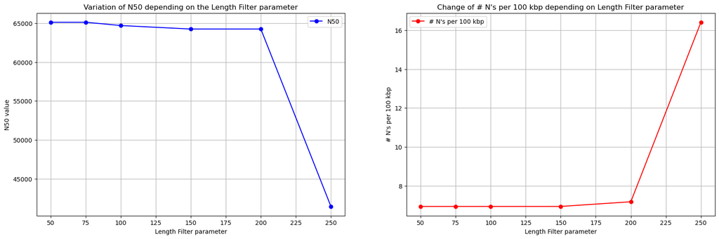

```python
# Data filtering for the "Length Filter" trimming method
length_filter_data = second_sorted_metrics_df[second_sorted_metrics_df['Trimming Parameters'].str.contains('LengthFilter')]

# Extracting Length Filter parameters from 'Trimming Parameters' and sorting by them for line continuity
length_filter_params_and_data = length_filter_data['Trimming Parameters'].str.extract('LengthFilter_(\d+)')[0].astype(int)
length_filter_sorted = length_filter_params_and_data.sort_values().index
length_filter_params = length_filter_params_and_data.loc[length_filter_sorted].astype(int)

# Creating a figure and a set of subplots
fig, axs = plt.subplots(1, 2, figsize=(20, 6))  # 1 row, 2 columns

# Plotting N50 with lines connecting points on the first subplot
axs[0].plot(length_filter_params, length_filter_data.loc[length_filter_sorted, 'N50'], marker='o', linestyle='-', color='blue', label='N50')
axs[0].set_title('Variation of N50 depending on the Length Filter parameter')
axs[0].set_xlabel('Length Filter parameter')
axs[0].set_ylabel('N50 value')
axs[0].grid(True)
axs[0].legend()

# Plotting # N's per 100 kbp with lines connecting points on the second subplot
axs[1].plot(length_filter_params, length_filter_data.loc[length_filter_sorted, "# N's per 100 kbp"], marker='o', linestyle='-', color='red', label="# N's per 100 kbp")
axs[1].set_title("Change of # N's per 100 kbp depending on Length Filter parameter")
axs[1].set_xlabel('Length Filter parameter')
axs[1].set_ylabel("# N's per 100 kbp")
axs[1].grid(True)
axs[1].legend()

plt.show()
```

**What conclusions can be drawn from this?**

1. Now, the inverse relationship between N50 and # N's per 100 kbp is visible.
2. Thanks to this demonstration, we can see how the value of the **Length Filter** method parameter affects the quality of genome assembly.
3. If we run the program pipeline again, applying the **Length Filter** trimming method with parameters around 75-50 values and below, we will likely be able to find an even better way to further enhance the quality of genome assembly.

Now we want to take the **Sliding Window** trimming method and use the 3D scatter plot to demonstrate how the N_Ratio_x10k of this trimming method changes as a function of its parameters. To visualize it we first need to filter the data to include only those rows that correspond to the different **Sliding Window** parameters. Then we can create the 3D scatter plot.

This code below is based on the fact that the trimming parameters for **Sliding Window** include two parameters (like window size and quality threshold) and that they are formatted in a recognizable pattern (e.g., **SlidingWindow_4nt_q20**):

```python
import plotly.graph_objects as go

# Filter data for the "Sliding Window" trimming method
sliding_window_data = second_sorted_metrics_df[second_sorted_metrics_df['Trimming Parameters'].str.startswith('SlidingWindow')]

# Extract and prepare the Sliding Window parameters for plotting
window_sizes = sliding_window_data['Trimming Parameters'].str.extract('(\d+)nt')[0].astype(int)
quality_thresholds = sliding_window_data['Trimming Parameters'].str.extract('q(\d+)')[0].astype(int)

# Create a 3D scatter plot for N50 using Plotly
fig = go.Figure(data=[go.Scatter3d(
    x=window_sizes,
    y=quality_thresholds,
    z=sliding_window_data['N_Ratio_x10k'],
    mode='markers',
    marker=dict(size=5, color='blue', opacity=0.8)
)])

fig.update_layout(title='3D Scatter Plot of N_Ratio_x10k for Sliding Window Trimming',
                 scene=dict(xaxis_title='Window Size',
                             yaxis_title='Quality Threshold',
                             zaxis_title='N_Ratio_x10k'))
# Display the plot inline in Jupyter Notebook
fig.show(renderer="iframe")
```

[interactive chart not shown]

**What conclusions can be drawn from this?**

1. Now, by opening this interactive 3D Scatter Plot (in the browser), we can observe each point in space along with its X, Y, and Z values. The values on the X and Y axes represent the numerical parameters of the **Sliding Window** trimming method (window size and mean quality), while the value on the Z axis corresponds to N_Ratio_x10k. The lower this value is, the better the compromise between # N's per 100 kbp and N50, and consequently, the higher the quality of the genome assembly.
2. We can identify the lowest point on this 3D Scatter Plot. This means that its X and Y values represent the optimal window size and mean quality values for this trimming method in terms of their impact on the subsequent genome assembly.
3. It is quite likely that if we initiate a third run of the software pipeline with window size and mean quality values near this point, we can further enhance the trimming quality.

```python
def extract_correct_metrics(report_file_path):
    try:
        df_correct = pd.read_csv(report_file_path, sep='\t', header=0)

        correct_metrics = {
            'Total length': df_correct.loc[0, 'Total length'],
            'GC (%)': df_correct.loc[0, 'GC (%)'],
            'Largest Contig': df_correct.loc[0, 'Largest contig'],
            'N50': df_correct.loc[0, 'N50'],
            'N90': df_correct.loc[0, 'N90'],
            'L50': df_correct.loc[0, 'L50'],
            'L90': df_correct.loc[0, 'L90'],
            "# N's per 100 kbp": df_correct.loc[0, "# N's per 100 kbp"]
        }

        return correct_metrics
    except Exception as e:
        print(f"Error processing {report_file_path}: {e}")
        return None


# New path to the directory with reports
third_reports_dir = './reports_3'

# List of report files in a new directory
third_report_files = [file for file in os.listdir(third_reports_dir) if file.endswith('.tsv')]

# Extracting and saving data from all report files
third_all_metrics_data = {}
for report_file in third_report_files:
    # Forming the full path to the report file
    third_report_path = os.path.join(third_reports_dir, report_file)
    # Determining the trimming parameter name from the third report file name
    third_trimming_param = report_file.replace('output_scaffolds_', '').replace('.tsv', '')
    # Extracting metrics
    third_metrics = extract_correct_metrics(third_report_path)
    if third_metrics:
        third_all_metrics_data[third_trimming_param] = third_metrics


# Converting the data into a DataFrame
third_all_metrics_df = pd.DataFrame.from_dict(third_all_metrics_data, orient='index').reset_index()
third_all_metrics_df.rename(columns={'index': 'Trimming Parameters'}, inplace=True)

# List of trimming parameters in the desired order
third_sorting_order = [
    "SlidingWindow_3nt_q30",
    "SlidingWindow_4nt_q30",
    "SlidingWindow_4nt_q29",
    "SlidingWindow_5nt_q30",
    "LengthFilter_30",
    "LengthFilter_35",
    "LengthFilter_40",
    "LengthFilter_45",
    "LengthFilter_50",
    "LengthFilter_55",
]

# Sorting the DataFrame according to the specified order
third_sorted_metrics_df = third_all_metrics_df.set_index('Trimming Parameters').reindex(third_sorting_order).reset_index()

third_sorted_metrics_df
```

|  | Trimming Parameters | Total length | GC (%) | Largest Contig | N50 | N90 | L50 | L90 | # N's per 100 kbp |
| --- | --- | --- | --- | --- | --- | --- | --- | --- | --- |
| 0 | SlidingWindow_3nt_q30 | 4302594 | 65.40 | 139540 | 38864 | 10691 | 34 | 111 | 1.86 |
| 1 | SlidingWindow_4nt_q30 | 4310805 | 65.42 | 156069 | 45172 | 12240 | 31 | 100 | 4.64 |
| 2 | SlidingWindow_4nt_q29 | 4314963 | 65.43 | 161279 | 49758 | 12487 | 29 | 94 | 6.49 |
| 3 | SlidingWindow_5nt_q30 | 4315324 | 65.43 | 161302 | 45552 | 12261 | 31 | 98 | 6.49 |
| 4 | LengthFilter_30 | 4321024 | 65.41 | 209097 | 65136 | 17421 | 19 | 64 | 6.94 |
| 5 | LengthFilter_35 | 4321024 | 65.41 | 209097 | 65136 | 17421 | 19 | 64 | 6.94 |
| 6 | LengthFilter_40 | 4321012 | 65.41 | 209097 | 65136 | 17421 | 19 | 64 | 6.94 |
| 7 | LengthFilter_45 | 4321017 | 65.41 | 209097 | 65136 | 17421 | 19 | 64 | 6.94 |
| 8 | LengthFilter_50 | 4321006 | 65.41 | 209097 | 65136 | 17421 | 19 | 64 | 6.94 |
| 9 | LengthFilter_55 | 4321006 | 65.41 | 209097 | 65136 | 17421 | 19 | 64 | 6.94 |

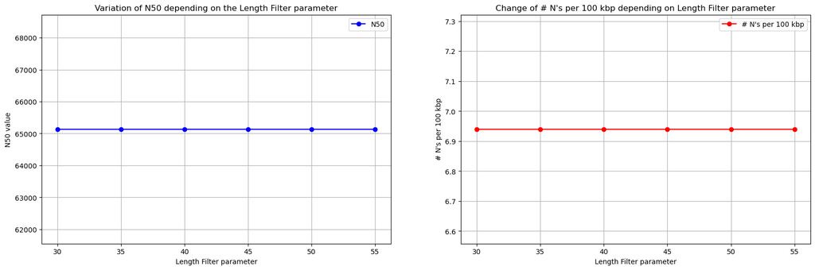

```python
# Data filtering for the "Length Filter" trimming method
length_filter_data = third_sorted_metrics_df[third_sorted_metrics_df['Trimming Parameters'].str.contains('LengthFilter')]

# Extracting Length Filter parameters from 'Trimming Parameters' and sorting by them for line continuity
length_filter_params_and_data = length_filter_data['Trimming Parameters'].str.extract('LengthFilter_(\d+)')[0].astype(int)
length_filter_sorted = length_filter_params_and_data.sort_values().index
length_filter_params = length_filter_params_and_data.loc[length_filter_sorted].astype(int)

# Creating a figure and a set of subplots
fig, axs = plt.subplots(1, 2, figsize=(20, 6))  # 1 row, 2 columns

# Plotting N50 with lines connecting points on the first subplot
axs[0].plot(length_filter_params, length_filter_data.loc[length_filter_sorted, 'N50'], marker='o', linestyle='-', color='blue', label='N50')
axs[0].set_title('Variation of N50 depending on the Length Filter parameter')
axs[0].set_xlabel('Length Filter parameter')
axs[0].set_ylabel('N50 value')
axs[0].grid(True)
axs[0].legend()

# Plotting # N's per 100 kbp with lines connecting points on the second subplot
axs[1].plot(length_filter_params, length_filter_data.loc[length_filter_sorted, "# N's per 100 kbp"], marker='o', linestyle='-', color='red', label="# N's per 100 kbp")
axs[1].set_title("Change of # N's per 100 kbp depending on Length Filter parameter")
axs[1].set_xlabel('Length Filter parameter')
axs[1].set_ylabel("# N's per 100 kbp")
axs[1].grid(True)
axs[1].legend()

plt.show()
```

**What conclusions can be drawn from this?**

1. As we can see in the graph, we found no improvement in changing the value of the trimming method near its best previous value.
2. Our hypothesis did not come true.

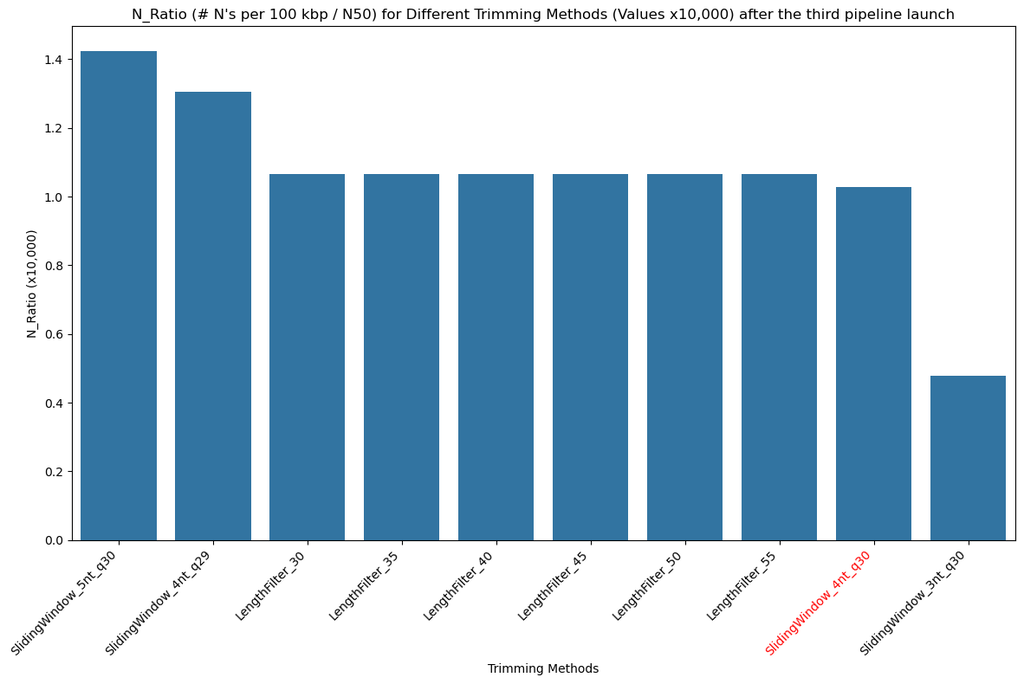

```python
# Calculate the relationship and add it as a new column to the DataFrame multiplying the result by 10,000
third_sorted_metrics_df['N_Ratio_x10k'] = (third_sorted_metrics_df['# N\'s per 100 kbp'] / third_sorted_metrics_df['N50']) * 10000

# Sort the DataFrame by the new column 'N_Ratio'
third_sorted_df = third_sorted_metrics_df.sort_values(by='N_Ratio_x10k', ascending=False)

# Visualisation on one common graph
plt.figure(figsize=(12, 8))
barplot = sns.barplot(x='Trimming Parameters', y='N_Ratio_x10k', data=third_sorted_df)

plt.title('N_Ratio (# N\'s per 100 kbp / N50) for Different Trimming Methods (Values x10,000) after the third pipeline launch')
plt.xlabel('Trimming Methods')
plt.ylabel('N_Ratio (x10,000)')

# Change the colour of the 'NoTrimming' signature to red
for label in barplot.get_xticklabels():
    if label.get_text() == 'SlidingWindow_4nt_q30':
        label.set_color('red')

plt.xticks(rotation=45, ha='right')  # Tilt signatures for better readability

plt.tight_layout()
plt.show()
```

**What conclusions can be drawn from this?**

1. Our hypothesis came true and we found an even better way to trim the data with new parameters - **SlidingWindow_3nt_q30**.

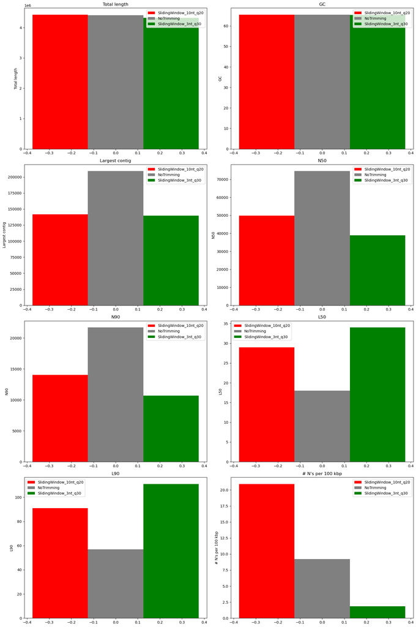

```python
import pandas as pd
import numpy as np
import matplotlib.pyplot as plt

# Function to extract metrics
def extract_metrics_adjusted(path, metrics_of_interest):
    df = pd.read_csv(path, sep='\t', header=0)  # Reading without setting the index
    metrics_dict = {}
    for metric_name, metric_col in metrics_of_interest:
        if metric_col in df.columns:
            metrics_dict[metric_name] = df[metric_col].iloc[0]  # Assuming metrics are in the first row
        else:
            # Trying to find the metric in a row-wise layout
            metric_row = df[df['Assembly'].str.contains(metric_name, case=False, na=False)]
            if not metric_row.empty:
                metrics_dict[metric_name] = metric_row.iloc[0, 1]  # Taking the value from the second column
            else:
                metrics_dict[metric_name] = None  # Metric not found
    return pd.Series(metrics_dict)

# Paths to the files
paths = [
    './TrialsExtremes/output_scaffolds_SlidingWindow_10nt_q20.tsv',
    './TrialsExtremes/output_scaffolds_NoTrimming.tsv',
    './TrialsExtremes/output_scaffolds_SlidingWindow_3nt_q30.tsv'
]

# Metrics of interest
metrics_list = [
    ('Total length', 'Total length (>= 0 bp)'),
    ('GC', 'GC (%)'),
    ('Largest contig', 'Largest contig'),
    ('N50', 'N50'),
    ('N90', 'N90'),
    ('L50', 'L50'),
    ('L90', 'L90'),
    ("# N's per 100 kbp", "# N's per 100 kbp")
]

# Number of plots per row
plots_per_row = 2
num_metrics = len(metrics_list)
num_rows = np.ceil(num_metrics / plots_per_row).astype(int)

# Create figure with subplots
fig, axes = plt.subplots(num_rows, plots_per_row, figsize=(plots_per_row * 8, num_rows * 6))
axes = axes.flatten()  # Flatten the axes array for easy indexing

# Colors for each trimming method
colors = {
    'SlidingWindow_10nt_q20': 'r',
    'NoTrimming': 'gray',
    'SlidingWindow_3nt_q30': 'g'
}

for i, (metric_name, metric_col) in enumerate(metrics_list):
    # Extract and combine metrics for the current metric
    adjusted_metrics = [extract_metrics_adjusted(path, [(metric_name, metric_col)]) for path in paths]
    combined_metrics_df = pd.concat(adjusted_metrics, axis=1)
    combined_metrics_df.columns = ['SlidingWindow_10nt_q20', 'NoTrimming', 'SlidingWindow_3nt_q30']

    # Create grouped bar chart
    ax = axes[i]
    n_groups = 1  # One group for each metric
    bar_width = 0.25
    index = np.arange(n_groups)
    positions = [index - bar_width, index, index + bar_width]

    for j, label in enumerate(combined_metrics_df.columns):
        ax.bar(positions[j], combined_metrics_df[label], color=colors[label], width=bar_width, label=label)

    ax.set_ylabel(metric_name)
    ax.set_title(f'{metric_name}')
    ax.legend()

# Hide any unused axes
for i in range(num_metrics, num_rows * plots_per_row):
    fig.delaxes(axes[i])

fig.tight_layout()
plt.show()
```

## Practical Applications of the Optimal Trimming Method

The results of the research on selecting the best trimming method offer several significant practical advantages:

1. **Improved Quality of Genome Assemblies**: Applying the optimal trimming method significantly enhances the quality of genome assembly, which is crucial for subsequent analyses and studies. This leads to more accurate and reliable results in genome research.
2. **Time and Resource Savings**: Optimizing the trimming process can reduce the time and resources spent on genome data analysis. Improving data quality on the first attempt decreases the need for re-analysis and adjustments.
3. **Enhanced Diagnostic and Research Procedures**: In medical and biological research, the accuracy of genome data is critical. Improved trimming methods contribute to more precise disease diagnoses and a more detailed study of genetic characteristics of various organisms.
4. **Development of Standards and Recommendations**: Research findings can be used to develop standards and recommendations for genome data processing, helping other researchers and laboratories improve their workflows.
5. **Reduction of Errors and Artifacts**: The optimal trimming method reduces the number of errors and artifacts in the data, increasing its reliability and validity. This is important for further analysis and data interpretation.
6. **Competitive Advantage**: Laboratories and research groups using the best trimming methods can achieve higher quality results, giving them a competitive edge in genome research.

In summary, the identified trimming method ensures higher data quality, saves resources, and improves the reliability of results, which is highly valuable for practical applications in genome research and medicine.

## Scientific Applications

The results of the study and the optimized trimming method can be applied in various scientific fields:

1. **Genomics and Genetics**:
   - **Human Genome Research**: Optimization of trimming methods helps improve the quality of data used to study genetic variations, hereditary diseases, and individual genome features.
   - **Genomic Projects and Consortia**: Projects like the Human Genome Project and other international initiatives can use the best trimming methods to enhance data accuracy.
2. **Medical Research**:
   - **Disease Diagnosis**: Higher quality genome data aids in more accurate diagnosis of genetic diseases and the development of personalized treatment methods.
   - **Oncogenomics**: Study of genetic changes in cancer cells to identify mutations associated with cancer and develop targeted therapies.
3. **Pharmacogenomics**:
   - **Drug Development**: Optimization of genome data helps identify genetic targets for new drugs and assess their effectiveness and safety for different genetic groups.
4. **Evolutionary Biology**:
   - **Species Evolution Research**: Analysis of genome data from different species helps understand evolutionary processes and genetic diversification.
5. **Agrobiotechnology**:
   - **Plant and Animal Breeding**: Using optimized trimming methods to improve the quality of genome data, aiding in the breeding of new plant varieties and animal breeds with desired characteristics.
   - **Genetic Modification**: Accurate genome editing to create GMOs with improved traits such as disease resistance and stress tolerance.
6. **Microbiology and Biotechnology**:
   - **Metagenomics**: Study of microbiomes and ecosystems to understand their structure and function, and to develop new biotechnological applications.
   - **Bioremediation**: Use of microorganisms to clean up contaminated environments, where precise understanding of their genomic functions is crucial.
7. **Clinical Research and Personalized Medicine**:
   - **Personalized Therapy**: Application of genome data for the selection of individualized treatment strategies based on the patient's genetic characteristics.

Applying optimized trimming methods in these scientific fields leads to more accurate and reliable data, which in turn drives significant scientific and practical advancements.